# 重賞レース予測レポート【毎時自動更新中】

作成日時: 2026/05/10 10:04:57

☞ [マニュアル(pdf)](https://ryutoro-galois.github.io/keiba-predictor/manual/manual.pdf)

☞ 過去4週間の別レース結果: [1週前(5/2-3)](https://ryutoro-galois.github.io/keiba-predictor/report/PredResult_2026y_raceDate_20260502_20260503.html), [2週前(4/25-26)](https://ryutoro-galois.github.io/keiba-predictor/report/PredResult_2026y_raceDate_20260425_20260426.html), [3週前(4/18-19)](https://ryutoro-galois.github.io/keiba-predictor/report/PredResult_2026y_raceDate_20260418_20260419.html), [4週前(4/11-12)](https://ryutoro-galois.github.io/keiba-predictor/report/PredResult_2026y_raceDate_20260411_20260412.html)

☞ netkeiba: [エプソムカップ(GⅢ)](https://race.netkeiba.com/race/shutuba.html?race_id=202605020511&rf=race_list), [京都新聞杯(GⅡ)](https://race.netkeiba.com/race/shutuba.html?race_id=202608030511&rf=race_list), [NHKマイルカップ(GⅠ)](https://race.netkeiba.com/race/shutuba.html?race_id=202605020611&rf=race_list)

## 0. 推し馬予測 (AI予測)

### 【エプソムカップ(GⅢ) 2026/05/09(土)】

- 本命(◎): 1-3着内確率(勝負強さ)が1位の馬
- 対抗(◯): 1-3着内確率が2-N位(20%程度以上)の中で予測タイムが最も速い馬
- 3番手(▲): 1-3着内確率が2-N位(20%程度以上)のでダークホース確率が最も高い馬
- 穴: ダークホース確率が上位1-M位(40%程度以上)の中で1-3着内確率が最も高い馬

| 推し馬 | 枠番 | 馬番 | 人気 | オッズ | 馬名 | 騎手 | 調教師 | 予測タイム(sec) | 1_順位 | 1-3着内確率(%) | 2_順位 | ﾀﾞｰｸﾎｰｽ確率(%) | 3_順位 |
| --- | --- | --- | --- | --- | --- | --- | --- | --- | --- | --- | --- | --- | --- |
| 本命(◎) | 2 | 4 | 3 | 4.8 | カラマティアノス | 津村明秀 | 奥村武 | 106.3 | 4.0 | 45.1 | 1 | 0.4 | 17 |
| 対抗(◯) | 3 | 6 | 6 | 17.4 | マジックサンズ | 横山和生 | 須貝尚介 | 105.4 | 1.5 | 22.6 | 5 | 1.2 | 11 |
| 3番手(▲) | 8 | 16 | 5 | 17.0 | ステレンボッシュ | 戸崎圭太 | 宮田敬介 | 109.7 | 8.0 | 25.6 | 3 | 1.3 | 9 |
| 穴 | 2 | 3 | 17 | 188.6 | エピファニー | 杉原誠人 | 宮田敬介 | 115.8 | 15.0 | 14.4 | 7 | 56.9 | 1 |

### 【京都新聞杯(GⅡ) 2026/05/09(土)】

- 本命(◎): 1-3着内確率(勝負強さ)が1位の馬
- 対抗(◯): 1-3着内確率が2-N位(20%程度以上)の中で予測タイムが最も速い馬
- 3番手(▲): 1-3着内確率が2-N位(20%程度以上)のでダークホース確率が最も高い馬
- 穴: ダークホース確率が上位1-M位(40%程度以上)の中で1-3着内確率が最も高い馬

| 推し馬 | 枠番 | 馬番 | 人気 | オッズ | 馬名 | 騎手 | 調教師 | 予測タイム(sec) | 1_順位 | 1-3着内確率(%) | 2_順位 | ﾀﾞｰｸﾎｰｽ確率(%) | 3_順位 |
| --- | --- | --- | --- | --- | --- | --- | --- | --- | --- | --- | --- | --- | --- |
| 本命(◎) | 8 | 15 | 1 | 2.1 | ベレシート | 北村友一 | 斉藤崇史 | 130.0 | 1.0 | 51.5 | 1 | 0.8 | 14 |
| 対抗(◯) | 1 | 2 | 2 | 4.6 | エムズビギン | 川田将雅 | 友道康夫 | 137.6 | 2.0 | 25.4 | 2 | 0.7 | 15 |
| 3番手(▲) | 1 | 1 | 3 | 9.3 | アーレムアレス | 菱田裕二 | 橋口慎介 | 138.3 | 6.5 | 20.6 | 3 | 0.7 | 16 |
| 穴 | 5 | 9 | 11 | 36.3 | カフジエメンタール | 吉村誠之助 | 矢作芳人 | 138.4 | 8.0 | 12.4 | 8 | 46.5 | 4 |

### 【NHKマイルカップ(GⅠ) 2026/05/10(日)】

- 本命(◎): 1-3着内確率(勝負強さ)が1位の馬
- 対抗(◯): 1-3着内確率が2-N位(20%程度以上)の中で予測タイムが最も速い馬
- 3番手(▲): 1-3着内確率が2-N位(20%程度以上)のでダークホース確率が最も高い馬
- 穴: ダークホース確率が上位1-M位(40%程度以上)の中で1-3着内確率が最も高い馬

| 推し馬 | 枠番 | 馬番 | 人気 | オッズ | 馬名 | 騎手 | 調教師 | 予測タイム(sec) | 1_順位 | 1-3着内確率(%) | 2_順位 | ﾀﾞｰｸﾎｰｽ確率(%) | 3_順位 |
| --- | --- | --- | --- | --- | --- | --- | --- | --- | --- | --- | --- | --- | --- |
| 本命(◎) | 8 | 17 | 3 | 6.0 | ロデオドライブ | Ｄ．レーン | 辻哲英 | 102.9 | 15.0 | 25.3 | 1 | 1.5 | 15 |
| 対抗(◯) | 5 | 10 | 2 | 5.2 | エコロアルバ | 横山和生 | 田村康仁 | 95.3 | 5.0 | 22.2 | 2 | 1.4 | 16 |
| 3番手(▲) | 3 | 5 | 13 | 32.2 | ギリーズボール | 西塚洸二 | 手塚貴久 | 91.4 | 2.5 | 16.3 | 5 | 57.3 | 4 |
| 穴 | 7 | 13 | 17 | 93.1 | ハッピーエンジェル | 三浦皇成 | 武市康男 | 91.4 | 2.5 | 10.2 | 8 | 63.8 | 1 |

## 1. 予測チャート (タイム/勝負強さ)

### 【エプソムカップ(GⅢ)】

2026/05/09(土), 05_東京, 芝左1800m

[interactive chart not shown]

### 【京都新聞杯(GⅡ)】

2026/05/09(土), 08_京都, 芝右外2200m

[interactive chart not shown]

### 【NHKマイルカップ(GⅠ)】

2026/05/10(日), 05_東京, 芝左1600m

[interactive chart not shown]

## 2. オッズモニタリング (毎時)

### 【エプソムカップ】

[interactive chart not shown]

### 【京都新聞杯】

[interactive chart not shown]

### 【NHKマイルカップ】

[interactive chart not shown]

## 3. 出馬表

### 【エプソムカップ 2026/05/09(土) 】

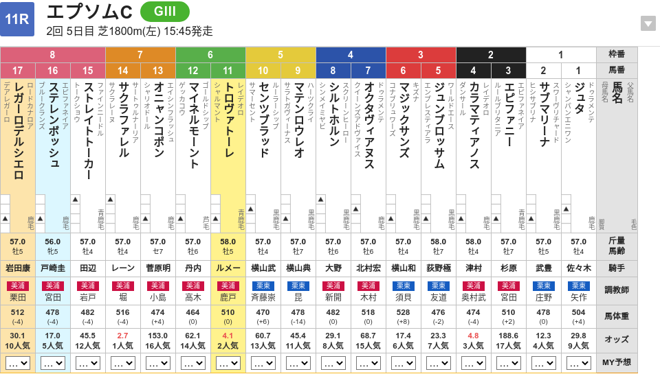

### 【京都新聞杯 2026/05/09(土) 】

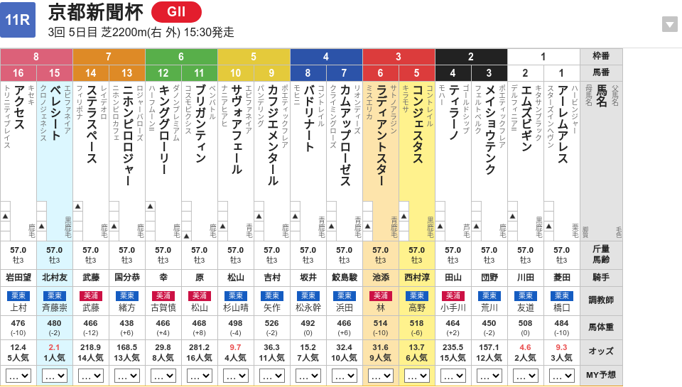

### 【NHKマイルカップ 2026/05/10(日) 】

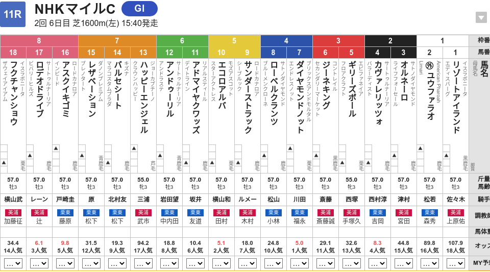

## 4. 単勝予測結果

### 【エプソムカップ(GⅢ) 2026/05/09(土)】

| 枠番 | 馬番 | 人気 | オッズ | 馬名 | 騎手 | 調教師 | 予測タイム(sec) | 1_順位 | 1-3着内確率(%) | 2_順位 | ﾀﾞｰｸﾎｰｽ確率(%) | 3_順位 |
| --- | --- | --- | --- | --- | --- | --- | --- | --- | --- | --- | --- | --- |
| 1 | 1 | 9 | 29.8 | ジュタ | 佐々木大輔 | 矢作芳人 | 106.6 | 5.0 | 11.6 | 9 | 1.3 | 10 |
| 1 | 2 | 4 | 12.3 | サブマリーナ | 武豊 | 庄野靖志 | 114.2 | 11.0 | 23.7 | 4 | 1.1 | 13 |
| 2 | 3 | 17 | 188.6 | エピファニー | 杉原誠人 | 宮田敬介 | 115.8 | 15.0 | 14.4 | 7 | 56.9 | 1 |
| 2 | 4 | 3 | 4.8 | カラマティアノス | 津村明秀 | 奥村武 | 106.3 | 4.0 | 45.1 | 1 | 0.4 | 17 |
| 3 | 5 | 7 | 23.3 | ジュンブロッサム | 荻野極 | 友道康夫 | 114.9 | 14.0 | 14.1 | 8 | 1.2 | 12 |
| 3 | 6 | 6 | 17.4 | マジックサンズ | 横山和生 | 須貝尚介 | 105.4 | 1.5 | 22.6 | 5 | 1.2 | 11 |
| 4 | 7 | 15 | 68.7 | オクタヴィアヌス | 北村宏司 | 木村哲也 | 114.5 | 13.0 | 5.8 | 16 | 18.2 | 6 |
| 4 | 8 | 8 | 29.1 | シルトホルン | 大野拓弥 | 新開幸一 | 114.3 | 12.0 | 3.1 | 17 | 0.8 | 14 |
| 5 | 9 | 11 | 45.4 | マテンロウレオ | 横山典弘 | 昆貢 | 116.6 | 16.0 | 6.5 | 15 | 14.5 | 7 |
| 5 | 10 | 13 | 60.7 | センツブラッド | 横山武史 | 斉藤崇史 | 106.6 | 6.5 | 9.5 | 10 | 34.0 | 3 |

[output cut: 7 more lines]

### 【京都新聞杯(GⅡ) 2026/05/09(土)】

| 枠番 | 馬番 | 人気 | オッズ | 馬名 | 騎手 | 調教師 | 予測タイム(sec) | 1_順位 | 1-3着内確率(%) | 2_順位 | ﾀﾞｰｸﾎｰｽ確率(%) | 3_順位 |
| --- | --- | --- | --- | --- | --- | --- | --- | --- | --- | --- | --- | --- |
| 1 | 1 | 3 | 9.3 | アーレムアレス | 菱田裕二 | 橋口慎介 | 138.3 | 6.5 | 20.6 | 3 | 0.7 | 16 |
| 1 | 2 | 2 | 4.6 | エムズビギン | 川田将雅 | 友道康夫 | 137.6 | 2.0 | 25.4 | 2 | 0.7 | 15 |
| 2 | 3 | 12 | 157.1 | メイショウテンク | 団野大成 | 荒川義之 | 138.4 | 9.0 | 7.1 | 11 | 33.2 | 6 |
| 2 | 4 | 15 | 235.5 | ティラーノ | 田山旺佑 | 小手川準 | 139.7 | 16.0 | 4.5 | 14 | 14.1 | 8 |
| 3 | 5 | 6 | 13.7 | コンジェスタス | 西村淳也 | 高野友和 | 138.4 | 10.0 | 17.6 | 5 | 1.1 | 11 |
| 3 | 6 | 9 | 31.6 | ラディアントスター | 池添謙一 | 林徹 | 138.2 | 3.0 | 10.7 | 9 | 52.4 | 3 |
| 4 | 7 | 10 | 32.4 | カムアップローゼス | 鮫島克駿 | 浜田多実雄 | 138.6 | 11.0 | 7.1 | 12 | 37.1 | 5 |
| 4 | 8 | 7 | 15.2 | バドリナート | 坂井瑠星 | 松永幹夫 | 138.3 | 6.5 | 17.2 | 7 | 1.2 | 10 |
| 5 | 9 | 11 | 36.3 | カフジエメンタール | 吉村誠之助 | 矢作芳人 | 138.4 | 8.0 | 12.4 | 8 | 46.5 | 4 |
| 5 | 10 | 4 | 9.7 | サヴォアフェール | 松山弘平 | 杉山晴紀 | 138.2 | 5.0 | 18.2 | 4 | 0.8 | 13 |

[output cut: 6 more lines]

### 【NHKマイルカップ(GⅠ) 2026/05/10(日)】

| 枠番 | 馬番 | 人気 | オッズ | 馬名 | 騎手 | 調教師 | 予測タイム(sec) | 1_順位 | 1-3着内確率(%) | 2_順位 | ﾀﾞｰｸﾎｰｽ確率(%) | 3_順位 |
| --- | --- | --- | --- | --- | --- | --- | --- | --- | --- | --- | --- | --- |
| 1 | 1 | 18 | 107.2 | リゾートアイランド | 佐々木大輔 | 上原佑紀 | 97.6 | 14.0 | 4.4 | 16 | 14.9 | 9 |
| 1 | 2 | 16 | 91.2 | ユウファラオ | 松若風馬 | 森秀行 | 91.4 | 2.5 | 7.9 | 9 | 59.8 | 2 |
| 2 | 3 | 15 | 45.4 | オルネーロ | 津村明秀 | 宮田敬介 | 103.0 | 16.0 | 7.1 | 10 | 19.5 | 7 |
| 2 | 4 | 4 | 8.2 | カヴァレリッツォ | 西村淳也 | 吉岡辰弥 | 96.0 | 8.0 | 16.7 | 4 | 1.6 | 14 |
| 3 | 5 | 13 | 32.2 | ギリーズボール | 西塚洸二 | 手塚貴久 | 91.4 | 2.5 | 16.3 | 5 | 57.3 | 4 |
| 3 | 6 | 11 | 29.2 | ジーネキング | 斎藤新 | 斎藤誠 | 96.5 | 13.0 | 6.8 | 11 | 41.2 | 5 |
| 4 | 7 | 1 | 5.1 | ダイヤモンドノット | 川田将雅 | 福永祐一 | 91.4 | 2.5 | 16.8 | 3 | 1.4 | 17 |
| 4 | 8 | 10 | 24.6 | ローベルクランツ | 松山弘平 | 小林真也 | 96.4 | 12.0 | 5.5 | 15 | 37.5 | 6 |
| 5 | 9 | 7 | 18.0 | サンダーストラック | Ｃ．ルメール | 木村哲也 | 103.9 | 17.0 | 3.8 | 17 | 1.2 | 18 |
| 5 | 10 | 2 | 5.2 | エコロアルバ | 横山和生 | 田村康仁 | 95.3 | 5.0 | 22.2 | 2 | 1.4 | 16 |

[output cut: 8 more lines]

## 5. 人気と着順の乖離率推移

### 【エプソムカップ_1990y_2019y】

[interactive chart not shown]

### 【京都新聞杯_1990y_2019y】

[interactive chart not shown]

### 【NHKマイルカップ_1996y_2019y】

[interactive chart not shown]

### 【エプソムカップ_1990y_2019y】

| No | 開催年 | 不整合率(%) | 頭数 | 人気別着順(1-3位) | 人気別着順(全体) |
| --- | --- | --- | --- | --- | --- |
| 30 | 2019 | 40.5 | 13頭 | 5-7-1 | 5\|7\|1\|12\|9\|3\|6\|13\|8\|2\|11\|4\|10 |
| 29 | 2018 | 48.7 | 16頭 | 2-4-5 | 2\|4\|5\|3\|8\|9\|15\|12\|13\|11\|14\|6\|10\|1\|7\|16 |
| 28 | 2017 | 25.7 | 18頭 | 5-1-6 | 5\|1\|6\|12\|17\|2\|8\|3\|9\|11\|10\|7\|18\|15\|4\|13\|16\|14 |
| 27 | 2016 | 24.3 | 18頭 | 1-3-6 | 1\|3\|6\|2\|7\|8\|5\|12\|4\|9\|13\|15\|17\|18\|10\|14\|16\|11 |
| 26 | 2015 | 22.2 | 13頭 | 2-1-4 | 2\|1\|4\|3\|6\|7\|10\|5\|8\|12\|9\|11\|13 |
| 25 | 2014 | 45.4 | 17頭 | 2-4-8 | 2\|4\|8\|3\|9\|1\|14\|17\|15\|7\|13\|6\|11\|12\|5\|10\|16 |
| 24 | 2013 | 65.0 | 14頭 | 4-3-7 | 4\|3\|7\|6\|2\|8\|1\|10\|12\|5\|11\|13\|9\|14 |
| 23 | 2012 | 14.2 | 18頭 | 1-2-15 | 1\|2\|15\|4\|8\|3\|10\|14\|5\|11\|6\|9\|13\|16\|7\|18\|17\|12 |
| 22 | 2011 | 21.0 | 18頭 | 1-6-2 | 1\|6\|2\|10\|14\|4\|3\|13\|7\|12\|11\|8\|5\|16\|18\|15\|17\|9 |
| 21 | 2010 | 23.8 | 18頭 | 1-3-9 | 1\|3\|9\|4\|2\|5\|13\|8\|18\|10\|17\|6\|11\|14\|12\|7\|16\|15 |

[output cut: 20 more lines]

### 【京都新聞杯_1990y_2019y】

| No | 開催年 | 不整合率(%) | 頭数 | 人気別着順(1-3位) | 人気別着順(全体) |
| --- | --- | --- | --- | --- | --- |
| 30 | 2019 | 34.9 | 14頭 | 11-2-7 | 11\|2\|7\|10\|1\|4\|6\|3\|12\|9\|8\|13\|5\|14 |
| 29 | 2018 | 51.0 | 17頭 | 7-11-4 | 7\|11\|4\|2\|12\|13\|8\|17\|5\|1\|6\|10\|15\|9\|14\|16\|3 |
| 28 | 2017 | 32.7 | 12頭 | 2-1-6 | 2\|1\|6\|5\|4\|8\|3\|7\|11\|10\|9\|12 |
| 27 | 2016 | 20.3 | 14頭 | 1-9-4 | 1\|9\|4\|2\|3\|7\|6\|5\|14\|13\|8\|12\|11\|10 |
| 26 | 2015 | 24.3 | 16頭 | 2-1-6 | 2\|1\|6\|4\|3\|5\|10\|7\|12\|13\|8\|11\|15\|14\|9\|16 |
| 25 | 2014 | 44.1 | 17頭 | 3-8-5 | 3\|8\|5\|1\|2\|9\|7\|11\|15\|13\|17\|12\|6\|10\|4\|14\|18 |
| 24 | 2013 | 51.5 | 16頭 | 1-9-11 | 1\|9\|11\|10\|7\|6\|8\|12\|4\|16\|15\|3\|14\|5\|2\|13 |
| 23 | 2012 | 32.5 | 13頭 | 5-2-1 | 5\|2\|1\|10\|3\|9\|4\|11\|8\|7\|12\|6\|13 |
| 22 | 2011 | 58.2 | 15頭 | 3-2-10 | 3\|2\|10\|7\|8\|6\|4\|12\|11\|1\|9\|13\|15\|14\|5 |
| 21 | 2010 | 46.6 | 17頭 | 3-2-1 | 3\|2\|1\|10\|5\|6\|14\|15\|9\|13\|17\|16\|8\|12\|11\|4\|7 |

[output cut: 20 more lines]

### 【NHKマイルカップ_1996y_2019y】

[output not shown]

[output cut: 14 more lines]

## 6. 1-3番人気馬の着順分類予測

### 【エプソムカップ】

[output not shown]

### 【京都新聞杯】

| 分類 | 凡例 | 発生確率(%) | 当該レース | 当該レースランク | 直近1年間 |
| --- | --- | --- | --- | --- | --- |
| 1: 1番人気のみ (1_pop1) | 1 \| * \| * | 18.3 | 3.27 | 3.21 | 0.55 |
| 4: 1,2番人気のみ (4_pop12) | 1 \| 2 \| * | 18.3 | 0.73 | 0.71 | 0.00 |
| 5: 1,3番人気のみ (5_pop13) | 1 \| 3 \| * | 14.0 | 5.00 | 4.83 | 0.00 |
| 8: 1,2,3番人気すべて着外 (8_darkhorse) | * \| * \| * | 13.7 | 1.23 | 1.20 | 0.00 |
| 2: 2番人気のみ (2_pop2) | 2 \| * \| * | 10.8 | 0.35 | 0.38 | 0.16 |
| 6: 2,3番人気のみ (6_pop23) | 2 \| 3 \| * | 8.9 | 3.18 | 3.07 | 0.00 |
| 3: 3番人気のみ (3_pop3) | 3 \| * \| * | 8.6 | 1.54 | 1.51 | 0.00 |
| 7: 1,2,3番人気すべて着内 (7_pop123) | 1 \| 2 \| 3 | 7.3 | 0.44 | 0.43 | 0.00 |

### 【NHKマイルカップ】

| 分類 | 凡例 | 発生確率(%) | 当該レース | 当該レースランク | 直近1年間 |
| --- | --- | --- | --- | --- | --- |
| 1: 1番人気のみ (1_pop1) | 1 \| * \| * | 18.4 | 1.10 | 1.10 | 0.00 |
| 4: 1,2番人気のみ (4_pop12) | 1 \| 2 \| * | 18.2 | 1.37 | 1.37 | 0.00 |
| 8: 1,2,3番人気すべて着外 (8_darkhorse) | * \| * \| * | 14.3 | 1.08 | 1.08 | 0.00 |
| 5: 1,3番人気のみ (5_pop13) | 1 \| 3 \| * | 13.7 | 1.37 | 1.37 | 0.00 |
| 6: 2,3番人気のみ (6_pop23) | 2 \| 3 \| * | 10.1 | 1.51 | 1.51 | 0.00 |
| 2: 2番人気のみ (2_pop2) | 2 \| * \| * | 9.6 | 0.26 | 0.26 | 0.10 |
| 3: 3番人気のみ (3_pop3) | 3 \| * \| * | 8.4 | 2.55 | 2.55 | 0.00 |
| 7: 1,2,3番人気すべて着内 (7_pop123) | 1 \| 2 \| 3 | 7.2 | 0.00 | 0.00 | 0.00 |

## 7. 3連複予測結果

### 【エプソムカップ(GⅢ) 2026/05/09(土)】

| 分類 | 馬番 | 枠番 | 人気 | 平均予測タイム(sec) | 1-3着内確率(%) | ﾀﾞｰｸﾎｰｽ確率(%) | 馬名 | 騎手 | 調教師 |
| --- | --- | --- | --- | --- | --- | --- | --- | --- | --- |
| 6: 2,3番人気のみ (6_pop23) | 11-4-16 | 6-2-8 | 2-3-5 | 107.27 | 4.77 | 0.00 | トロヴァトーレ \| カラマティアノス \| ステレンボッシュ | Ｃ．ルメール \| 津村明秀 \| 戸崎圭太 | 鹿戸雄一 \| 奥村武 \| 宮田敬介 |
| 6: 2,3番人気のみ (6_pop23) | 11-4-2 | 6-2-1 | 2-3-4 | 108.77 | 4.42 | 0.00 | トロヴァトーレ \| カラマティアノス \| サブマリーナ | Ｃ．ルメール \| 津村明秀 \| 武豊 | 鹿戸雄一 \| 奥村武 \| 庄野靖志 |
| 6: 2,3番人気のみ (6_pop23) | 11-4-6 | 6-2-3 | 2-3-6 | 105.83 | 4.21 | 0.00 | トロヴァトーレ \| カラマティアノス \| マジックサンズ | Ｃ．ルメール \| 津村明秀 \| 横山和生 | 鹿戸雄一 \| 奥村武 \| 須貝尚介 |
| 7: 1,2,3番人気すべて着内 (7_pop123) | 14-11-4 | 7-6-2 | 1-2-3 | 105.83 | 3.40 | 0.00 | サクラファレル \| トロヴァトーレ \| カラマティアノス | Ｄ．レーン \| Ｃ．ルメール \| 津村明秀 | 堀宣行 \| 鹿戸雄一 \| 奥村武 |
| 3: 3番人気のみ (3_pop3) | 4-2-16 | 2-1-8 | 3-4-5 | 110.07 | 2.74 | 0.00 | カラマティアノス \| サブマリーナ \| ステレンボッシュ | 津村明秀 \| 武豊 \| 戸崎圭太 | 奥村武 \| 庄野靖志 \| 宮田敬介 |
| 6: 2,3番人気のみ (6_pop23) | 11-4-3 | 6-2-2 | 2-3-17 | 109.30 | 2.69 | 0.00 | トロヴァトーレ \| カラマティアノス \| エピファニー | Ｃ．ルメール \| 津村明秀 \| 杉原誠人 | 鹿戸雄一 \| 奥村武 \| 宮田敬介 |
| 6: 2,3番人気のみ (6_pop23) | 11-4-5 | 6-2-3 | 2-3-7 | 109.00 | 2.64 | 0.00 | トロヴァトーレ \| カラマティアノス \| ジュンブロッサム | Ｃ．ルメール \| 津村明秀 \| 荻野極 | 鹿戸雄一 \| 奥村武 \| 友道康夫 |
| 3: 3番人気のみ (3_pop3) | 4-16-6 | 2-8-3 | 3-5-6 | 107.13 | 2.61 | 0.00 | カラマティアノス \| ステレンボッシュ \| マジックサンズ | 津村明秀 \| 戸崎圭太 \| 横山和生 | 奥村武 \| 宮田敬介 \| 須貝尚介 |
| 2: 2番人気のみ (2_pop2) | 11-2-16 | 6-1-8 | 2-4-5 | 109.90 | 2.51 | 0.00 | トロヴァトーレ \| サブマリーナ \| ステレンボッシュ | Ｃ．ルメール \| 武豊 \| 戸崎圭太 | 鹿戸雄一 \| 庄野靖志 \| 宮田敬介 |
| 3: 3番人気のみ (3_pop3) | 4-2-6 | 2-1-3 | 3-4-6 | 108.63 | 2.42 | 0.00 | カラマティアノス \| サブマリーナ \| マジックサンズ | 津村明秀 \| 武豊 \| 横山和生 | 奥村武 \| 庄野靖志 \| 須貝尚介 |

[output cut: 670 more lines]

### 【京都新聞杯(GⅡ) 2026/05/09(土)】

| 分類 | 馬番 | 枠番 | 人気 | 平均予測タイム(sec) | 1-3着内確率(%) | ﾀﾞｰｸﾎｰｽ確率(%) | 馬名 | 騎手 | 調教師 |
| --- | --- | --- | --- | --- | --- | --- | --- | --- | --- |
| 7: 1,2,3番人気すべて着内 (7_pop123) | 15-2-1 | 8-1-1 | 1-2-3 | 135.30 | 2.70 | 0.00 | ベレシート \| エムズビギン \| アーレムアレス | 北村友一 \| 川田将雅 \| 菱田裕二 | 斉藤崇史 \| 友道康夫 \| 橋口慎介 |
| 4: 1,2番人気のみ (4_pop12) | 15-2-10 | 8-1-5 | 1-2-4 | 135.27 | 2.39 | 0.00 | ベレシート \| エムズビギン \| サヴォアフェール | 北村友一 \| 川田将雅 \| 松山弘平 | 斉藤崇史 \| 友道康夫 \| 杉山晴紀 |
| 4: 1,2番人気のみ (4_pop12) | 15-2-5 | 8-1-3 | 1-2-6 | 135.33 | 2.31 | 0.00 | ベレシート \| エムズビギン \| コンジェスタス | 北村友一 \| 川田将雅 \| 西村淳也 | 斉藤崇史 \| 友道康夫 \| 高野友和 |
| 4: 1,2番人気のみ (4_pop12) | 15-2-16 | 8-1-8 | 1-2-5 | 135.27 | 2.28 | 0.00 | ベレシート \| エムズビギン \| アクセス | 北村友一 \| 川田将雅 \| 岩田望来 | 斉藤崇史 \| 友道康夫 \| 上村洋行 |
| 4: 1,2番人気のみ (4_pop12) | 15-2-8 | 8-1-4 | 1-2-7 | 135.30 | 2.25 | 0.00 | ベレシート \| エムズビギン \| バドリナート | 北村友一 \| 川田将雅 \| 坂井瑠星 | 斉藤崇史 \| 友道康夫 \| 松永幹夫 |
| 5: 1,3番人気のみ (5_pop13) | 15-1-10 | 8-1-5 | 1-3-4 | 135.50 | 1.93 | 0.00 | ベレシート \| アーレムアレス \| サヴォアフェール | 北村友一 \| 菱田裕二 \| 松山弘平 | 斉藤崇史 \| 橋口慎介 \| 杉山晴紀 |
| 5: 1,3番人気のみ (5_pop13) | 15-1-5 | 8-1-3 | 1-3-6 | 135.57 | 1.87 | 0.00 | ベレシート \| アーレムアレス \| コンジェスタス | 北村友一 \| 菱田裕二 \| 西村淳也 | 斉藤崇史 \| 橋口慎介 \| 高野友和 |
| 5: 1,3番人気のみ (5_pop13) | 15-1-16 | 8-1-8 | 1-3-5 | 135.50 | 1.85 | 0.00 | ベレシート \| アーレムアレス \| アクセス | 北村友一 \| 菱田裕二 \| 岩田望来 | 斉藤崇史 \| 橋口慎介 \| 上村洋行 |
| 5: 1,3番人気のみ (5_pop13) | 15-1-8 | 8-1-4 | 1-3-7 | 135.53 | 1.82 | 0.00 | ベレシート \| アーレムアレス \| バドリナート | 北村友一 \| 菱田裕二 \| 坂井瑠星 | 斉藤崇史 \| 橋口慎介 \| 松永幹夫 |
| 1: 1番人気のみ (1_pop1) | 15-10-5 | 8-5-3 | 1-4-6 | 135.53 | 1.66 | 0.00 | ベレシート \| サヴォアフェール \| コンジェスタス | 北村友一 \| 松山弘平 \| 西村淳也 | 斉藤崇史 \| 杉山晴紀 \| 高野友和 |

[output cut: 550 more lines]

### 【NHKマイルカップ(GⅠ) 2026/05/10(日)】

| 分類 | 馬番 | 枠番 | 人気 | 平均予測タイム(sec) | 1-3着内確率(%) | ﾀﾞｰｸﾎｰｽ確率(%) | 馬名 | 騎手 | 調教師 |
| --- | --- | --- | --- | --- | --- | --- | --- | --- | --- |
| 7: 1,2,3番人気すべて着内 (7_pop123) | 7-10-17 | 4-5-8 | 1-2-3 | 96.53 | 0.94 | 0.00 | ダイヤモンドノット \| エコロアルバ \| ロデオドライブ | 川田将雅 \| 横山和生 \| Ｄ．レーン | 福永祐一 \| 田村康仁 \| 辻哲英 |
| 6: 2,3番人気のみ (6_pop23) | 10-17-4 | 5-8-2 | 2-3-4 | 98.07 | 0.94 | 0.00 | エコロアルバ \| ロデオドライブ \| カヴァレリッツォ | 横山和生 \| Ｄ．レーン \| 西村淳也 | 田村康仁 \| 辻哲英 \| 吉岡辰弥 |
| 6: 2,3番人気のみ (6_pop23) | 10-17-5 | 5-8-3 | 2-3-13 | 96.53 | 0.92 | 0.01 | エコロアルバ \| ロデオドライブ \| ギリーズボール | 横山和生 \| Ｄ．レーン \| 西塚洸二 | 田村康仁 \| 辻哲英 \| 手塚貴久 |
| 6: 2,3番人気のみ (6_pop23) | 10-17-16 | 5-8-8 | 2-3-5 | 98.03 | 0.89 | 0.00 | エコロアルバ \| ロデオドライブ \| アスクイキゴミ | 横山和生 \| Ｄ．レーン \| 戸崎圭太 | 田村康仁 \| 辻哲英 \| 藤原英昭 |
| 6: 2,3番人気のみ (6_pop23) | 10-17-11 | 5-8-6 | 2-3-6 | 98.07 | 0.87 | 0.00 | エコロアルバ \| ロデオドライブ \| アドマイヤクワッズ | 横山和生 \| Ｄ．レーン \| 坂井瑠星 | 田村康仁 \| 辻哲英 \| 友道康夫 |
| 5: 1,3番人気のみ (5_pop13) | 7-17-4 | 4-8-2 | 1-3-4 | 96.77 | 0.71 | 0.00 | ダイヤモンドノット \| ロデオドライブ \| カヴァレリッツォ | 川田将雅 \| Ｄ．レーン \| 西村淳也 | 福永祐一 \| 辻哲英 \| 吉岡辰弥 |
| 5: 1,3番人気のみ (5_pop13) | 7-17-5 | 4-8-3 | 1-3-13 | 95.23 | 0.69 | 0.01 | ダイヤモンドノット \| ロデオドライブ \| ギリーズボール | 川田将雅 \| Ｄ．レーン \| 西塚洸二 | 福永祐一 \| 辻哲英 \| 手塚貴久 |
| 3: 3番人気のみ (3_pop3) | 17-4-5 | 8-2-3 | 3-4-13 | 96.77 | 0.69 | 0.01 | ロデオドライブ \| カヴァレリッツォ \| ギリーズボール | Ｄ．レーン \| 西村淳也 \| 西塚洸二 | 辻哲英 \| 吉岡辰弥 \| 手塚貴久 |
| 5: 1,3番人気のみ (5_pop13) | 7-17-16 | 4-8-8 | 1-3-5 | 96.73 | 0.67 | 0.00 | ダイヤモンドノット \| ロデオドライブ \| アスクイキゴミ | 川田将雅 \| Ｄ．レーン \| 戸崎圭太 | 福永祐一 \| 辻哲英 \| 藤原英昭 |
| 3: 3番人気のみ (3_pop3) | 17-4-16 | 8-2-8 | 3-4-5 | 98.27 | 0.67 | 0.00 | ロデオドライブ \| カヴァレリッツォ \| アスクイキゴミ | Ｄ．レーン \| 西村淳也 \| 戸崎圭太 | 辻哲英 \| 吉岡辰弥 \| 藤原英昭 |

[output cut: 806 more lines]

## 8. 直近の全レース情報

[output not shown]